# Final Project: HIV/AIDS

Albert Liu

## Introduction

In this tutorial, we will be using datasets from the World Health Organization to show the prevalence, spread, and impact of HIV/AIDS. We will start by collecting and manipulating data into a dataframe, then performing exploratory data analysis and use machine learning techniques to test hypotheses.

## Required Datasets:

We will be using multiple datasets from the World Health Organization, the links can be found below:

Number of new HIV infections Data by country: http://apps.who.int/gho/data/node.main.HIVINCIDENCE?lang=en  
Number of deaths due to HIV/AIDS Estimate by country: http://apps.who.int/gho/data/node.main.623?lang=en

## 1. Getting Started

Now we have the data stored into newInfections_tab, we can see the country, number of new HIV infections, and new HIV infections(per 1000 uninfected population).

```r
newInfections_tab <- read_csv("C:\\Users\\Alex\\Desktop\\newInfections.csv")
newInfections_tab
```

```
## # A tibble: 195 x 3
##    X1                  `Number of new HIV infections` `New HIV infections~
##    <chr>               <chr>                          <chr>
##  1 Country             2016                           2016
##  2 Afghanistan         <1000 [<500– 3 000]            0.03 [0.01-0.1]
##  3 Albania             <500 [<200–<500]               0.08 [0.07-0.09]
##  4 Algeria             <1000 [<1000–<1000]            0.02 [0.02-0.03]
##  5 Andorra             No data                        No data
##  6 Angola              25 000 [18 000–32 000]         0.94 [0.69-1.23]
##  7 Antigua and Barbuda No data                        No data
##  8 Argentina           5 500 [ 4 700– 6 100]          0.13 [0.11-0.14]
##  9 Armenia             <500 [<200–<500]               0.09 [0.06-0.12]
## 10 Australia           1 100 [ 1 100– 1 200]          0.05 [0.05-0.05]
## # ... with 185 more rows
```

Now we want to tidy the data. First, we will be removing the ranges in the columns. Then We will be changing the column names and the column type. The columns type of `Number of new HIV infections` and `New HIV infections (per 1000 uninfected population)` is , we want to change that into a numeric type. Finally, we change columns with “No data” to NA,

```r
colnames(newInfections_tab) <- c("Country","Number of new HIV infections in 2016","New HIV infections (per 1000 uninfected population) in 2016")
newInfections_tab <- newInfections_tab[-1,]
newInfections_tab$newcol <- stringr::str_replace(newInfections_tab$`Number of new HIV infections in 2016`, '\\<', '')
newInfections_tab$newcol <- stringr::str_replace(newInfections_tab$newcol, '\\<', '')
newInfections_tab$newcol1 <- gsub("(.*)\\[.*", "\\1", newInfections_tab$newcol)
newInfections_tab$newcol2 <- gsub(" ", "\\1", newInfections_tab$newcol1)
newInfections_tab[2] <- NULL
newInfections_tab[3] <- NULL
newInfections_tab[3] <- NULL
colnames(newInfections_tab)[3] <- "Number of new HIV infections in 2016"
newInfections_tab$newcol <- gsub("(.*)\\[.*", "\\1", newInfections_tab$`New HIV infections (per 1000 uninfected population) in 2016`)
newInfections_tab[2] <- NULL
colnames(newInfections_tab)[3] <- "New HIV infections (per 1000 uninfected population) in 2016"
newInfections_tab[newInfections_tab=="Nodata"] <- NA
newInfections_tab[newInfections_tab=="No data"] <- NA
newInfections_tab$`Number of new HIV infections in 2016` <- as.numeric(as.character(newInfections_tab$`Number of new HIV infections in 2016`))
newInfections_tab$`New HIV infections (per 1000 uninfected population) in 2016` <- as.numeric(as.character(newInfections_tab$`New HIV infections (per 1000 uninfected population) in 2016`))
newInfections_tab
```

```
## # A tibble: 194 x 3
##    Country             `Number of new HIV in~ `New HIV infections (per 10~
##    <chr>                                <dbl>                        <dbl>
##  1 Afghanistan                          1000.                       0.0300
##  2 Albania                               500.                       0.0800
##  3 Algeria                              1000.                       0.0200
##  4 Andorra                                NA                       NA
##  5 Angola                              25000.                       0.940
##  6 Antigua and Barbuda                    NA                       NA
##  7 Argentina                            5500.                       0.130
##  8 Armenia                               500.                       0.0900
##  9 Australia                            1100.                       0.0500
## 10 Austria                                NA                       NA
## # ... with 184 more rows
```

Here we have data about the number of deaths due to HIV/AIDS for each country. We will be focusing on the number of deaths in 2016.

```r
hivDeaths_tab <- read_csv("C:\\Users\\Alex\\Desktop\\hivDeaths.csv")
hivDeaths_tab
```

```
## # A tibble: 195 x 5
##    X1       `Number of deaths d~ `Number of deaths d~ `Number of deaths d~
##    <chr>    <chr>                <chr>                <chr>
##  1 Country  2016                 2010                 2005
##  2 Afghani~ <500 [<200–<1000]    <500 [<200–<500]     <200 [<100–<500]
##  3 Albania  <100 [<100–<100]     <100 [<100–<100]     <100 [<100–<100]
##  4 Algeria  <200 [<200–<500]     <500 [<500–<500]     <500 [<500–<500]
##  5 Andorra  No data              No data              No data
##  6 Angola   11 000 [ 8 200–14 0~ 9 400 [ 7 000–12 00~ 7 600 [ 5 600– 9 70~
##  7 Antigua~ No data              No data              No data
##  8 Argenti~ 2 400 [ 1 800– 2 90~ 2 000 [ 1 600– 2 50~ 2 000 [ 1 600– 2 40~
##  9 Armenia  <200 [<100–<200]     <200 [<200–<500]     <200 [<100–<200]
## 10 Austral~ <500 [<500–<1000]    <1000 [<500–<1000]   <500 [<500–<1000]
## # ... with 185 more rows, and 1 more variable: `Number of deaths due to
## #   HIV/AIDS_3` <chr>
```

We will be tyding this data using the same methods for newInfections_tab.

```r
hivDeaths_tab[3] <- NULL
hivDeaths_tab[3] <- NULL
hivDeaths_tab[3] <- NULL
colnames(hivDeaths_tab) <- c("Country","Number of deaths due to HIV/AIDS in 2016")
hivDeaths_tab <- hivDeaths_tab[-1,]
hivDeaths_tab$newcol <- stringr::str_replace(hivDeaths_tab$`Number of deaths due to HIV/AIDS in 2016`, '\\<', '')
hivDeaths_tab$newcol <- stringr::str_replace(hivDeaths_tab$newcol, '\\<', '')
hivDeaths_tab$newcol1 <- gsub("(.*)\\[.*", "\\1", hivDeaths_tab$newcol)
hivDeaths_tab$newcol2 <- gsub(" ", "\\1", hivDeaths_tab$newcol1)
hivDeaths_tab[2] <- NULL
hivDeaths_tab[2] <- NULL
hivDeaths_tab[2] <- NULL
colnames(hivDeaths_tab)[2] <- "Number of deaths due to HIV/AIDS in 2016"
hivDeaths_tab[hivDeaths_tab=="Nodata"] <- NA
hivDeaths_tab$`Number of deaths due to HIV/AIDS in 2016` <- as.numeric(as.character(hivDeaths_tab$`Number of deaths due to HIV/AIDS in 2016`))
hivDeaths_tab
```

```
## # A tibble: 194 x 2
##    Country             `Number of deaths due to HIV/AIDS in 2016`
##    <chr>                                                    <dbl>
##  1 Afghanistan                                               500.
##  2 Albania                                                   100.
##  3 Algeria                                                   200.
##  4 Andorra                                                    NA
##  5 Angola                                                  11000.
##  6 Antigua and Barbuda                                        NA
##  7 Argentina                                                2400.
##  8 Armenia                                                   200.
##  9 Australia                                                 500.
## 10 Austria                                                    NA
## # ... with 184 more rows
```

We can now combine both tables to create a single table with information about number of deaths and number of new HIV/AIDS infections.

```r
newDF <- merge(newInfections_tab, hivDeaths_tab, by="Country")
newDF
```

```
##                                                  Country
## 1                                            Afghanistan
## 2                                                Albania
## 3                                                Algeria
## 4                                                Andorra
## 5                                                 Angola
## 6                                    Antigua and Barbuda
## 7                                              Argentina
## 8                                                Armenia
## 9                                              Australia
## 10                                               Austria
## 11                                            Azerbaijan
## 12                                               Bahamas
## 13                                               Bahrain
## 14                                            Bangladesh
```

[output cut: 765 more lines]

## 2. Exploratory Data Analysis

We can now being data analysis for our table.

```r
# Total number of new HIV infections in 2016
totalNew <- sum(newDF$`Number of new HIV infections in 2016`,na.rm=TRUE)
totalNew
```

```
## [1] 1533500
```

```r
# Total number of new HIV infections (per 1000 uninfected population) in 2016
totalNewI <- sum(newDF$`New HIV infections (per 1000 uninfected population) in 2016`,na.rm=TRUE)
totalNewI
```

```
## [1] 89.84
```

```r
# Total number of deaths due to HIV/AIDS in 2016
totalNew <- sum(newDF$`Number of deaths due to HIV/AIDS in 2016`,na.rm=TRUE)
totalNew
```

```
## [1] 949600
```

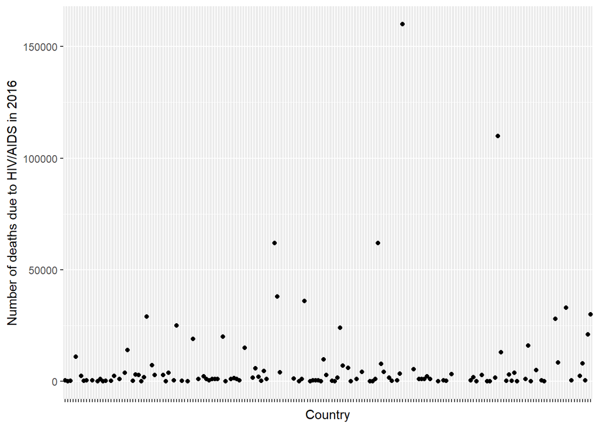

```r
# Plot of all countries and number of deaths due to HIV
newDF %>%
  ggplot(aes(x=Country,y=`Number of deaths due to HIV/AIDS in 2016`)) + geom_point() + theme(axis.text.x = element_blank())
```

The majority of countries have a low death count due to HIV.

```r
# Sort by number of new HIV infections in 2016
newDF1 <- newDF[order(newDF$`Number of new HIV infections in 2016`, decreasing=TRUE), ]
newDF1
```

```
##                                                  Country
## 160                                         South Africa
## 125                                              Nigeria
## 116                                           Mozambique
## 78                                                 India
## 89                                                 Kenya
## 193                                               Zambia
## 185                          United Republic of Tanzania
## 181                                               Uganda
## 24                                                Brazil
## 79                                             Indonesia
## 194                                             Zimbabwe
## 102                                               Malawi
## 31                                              Cameroon
## 59                                              Ethiopia
```

[output cut: 765 more lines]

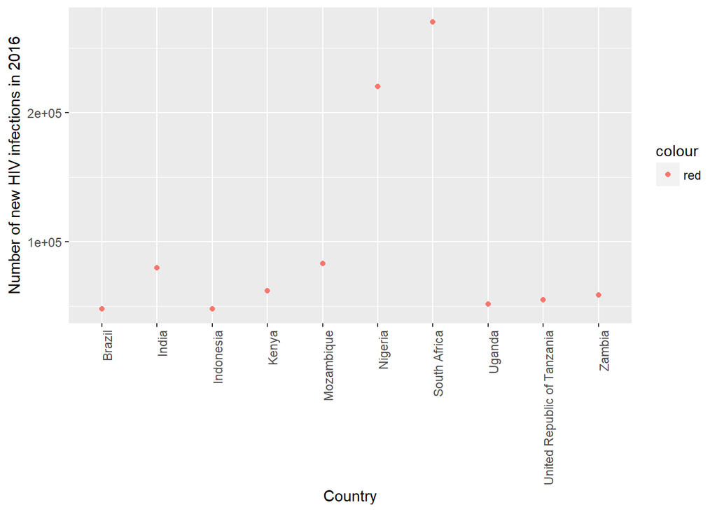

```r
# Plot of the top 10 countries with most number of new HIV infections in 2016
newDF1 <- newDF1[1:10, ]
newDF1 %>%
  ggplot(aes(x=Country,y=`Number of new HIV infections in 2016`,color="red")) + geom_point() + theme(axis.text.x = element_text(angle = 90, hjust = 1))
```

Seven out of ten countries with the highest number of new HIV infections are in Africa.

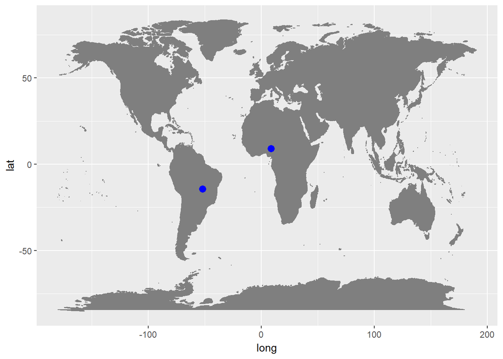

```r
# Map of the countries with highest number of new infections
countries <- c("Brazil","India", "Indonesia", "Kenya", "Mozambique", "Nigeria", "South Africa", "Uganda", "United Republic of Tanzania", "Zimbabwe")
ll.countries <- geocode(countries)
countries.x <- ll.countries$lon
countries.y <- ll.countries$lat
mapWorld <- borders("world", colour="gray50", fill="gray50")
mp <- ggplot() + mapWorld
mp <- mp + geom_point(aes(x=countries.x, y=countries.y) ,color="blue", size=3)
mp
```

```r
# Sort by number of deaths due to HIV/AIDS in 2016
newDF2 <- newDF[order(newDF$`Number of deaths due to HIV/AIDS in 2016`, decreasing=TRUE), ]
newDF2
```

```
##                                                  Country
## 125                                              Nigeria
## 160                                         South Africa
## 78                                                 India
## 116                                           Mozambique
## 79                                             Indonesia
## 89                                                 Kenya
## 185                          United Republic of Tanzania
## 194                                             Zimbabwe
## 31                                              Cameroon
## 181                                               Uganda
## 42                                         Côte d'Ivoire
## 102                                               Malawi
## 193                                               Zambia
## 59                                              Ethiopia
```

[output cut: 765 more lines]

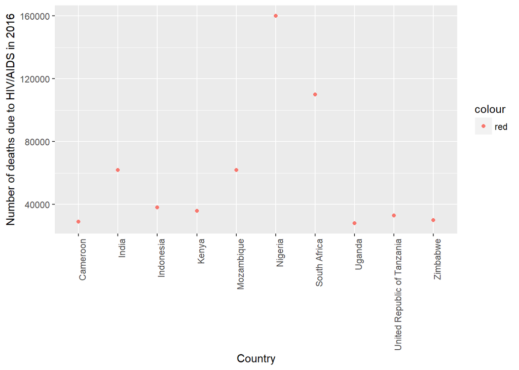

```r
# Plot of the top 10 countries with most number of deaths due to HIV/AIDS in 2016
newDF2 <- newDF2[1:10, ]
newDF2 %>%
  ggplot(aes(x=Country,y=`Number of deaths due to HIV/AIDS in 2016`,color="red")) + geom_point() + theme(axis.text.x = element_text(angle = 90, hjust = 1))
```

Eight out of ten countries with the highest number of deaths due to HIV are in Africa.

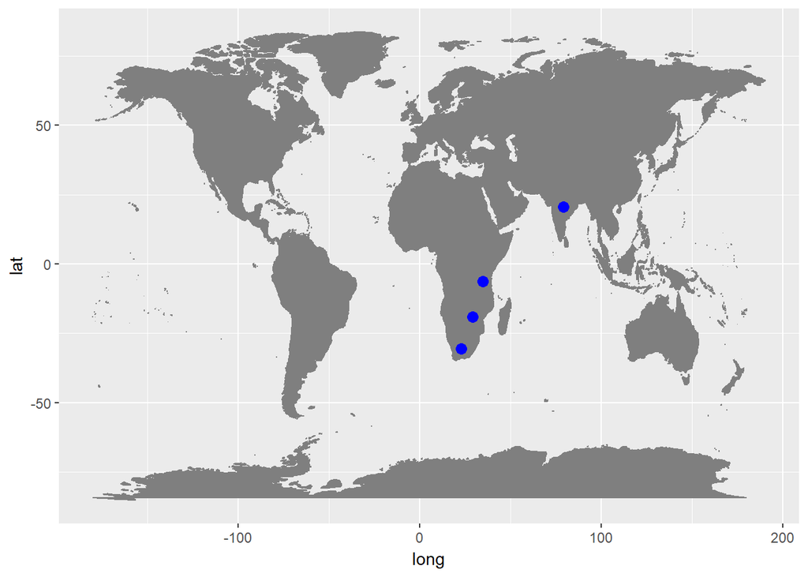

```r
# Map of the countries with highest number of deaths due to HIV
countries <- c("Cameroon","India", "Indonesia", "Kenya", "Mozambique", "Nigeria", "South Africa", "Uganda", "United Republic of Tanzania", "Zimbabwe")
ll.countries <- geocode(countries)
countries.x <- ll.countries$lon
countries.y <- ll.countries$lat
mapWorld <- borders("world", colour="gray50", fill="gray50")
mp <- ggplot() + mapWorld
mp <- mp + geom_point(aes(x=countries.x, y=countries.y) ,color="blue", size=3)
mp
```